# Grade Motivation

### [Home](https://pbischoff3.github.io/Projects/BIOL_3100) | [Data Overview](https://pbischoff3.github.io/Projects/BIOL_3100/data_overview/) | [Multi-Dimensional Analysis](https://pbischoff3.github.io/Projects/BIOL_3100/multi_dimensional_analysis/) | [Models](https://pbischoff3.github.io/Projects/BIOL_3100/models/) | [Conclusion](https://pbischoff3.github.io/Projects/BIOL_3100/Conclusion/)

#### [Science Identity](https://pbischoff3.github.io/Projects/BIOL_3100/models/si/) | [Career Motivation](https://pbischoff3.github.io/Projects/BIOL_3100/models/cm/) | [Intrinsic Motivation](https://pbischoff3.github.io/Projects/BIOL_3100/models/im/) | [Self-Determination](https://pbischoff3.github.io/Projects/BIOL_3100/models/sd/) | [Self-Efficacy](https://pbischoff3.github.io/Projects/BIOL_3100/models/se/) | [Grade Motivation](https://pbischoff3.github.io/Projects/BIOL_3100/models/gm) | [Personal Communal Orientation](https://pbischoff3.github.io/Projects/BIOL_3100/models/per_com_orient/) | [Analysis](https://pbischoff3.github.io/Projects/BIOL_3100/models/analysis/)

Let’s check out Grade Motivation models.

## Major

Let’s see the influence that the difference in majors have an the average of Grade Motivation questions:

```
##
## Call:
## glm(formula = grade_mot_ave ~ major, data = df)
##
## Deviance Residuals:
##     Min       1Q   Median       3Q      Max
## -3.5155  -0.0853   0.2416   0.4845   0.6938
##
## Coefficients:
##                   Estimate Std. Error t value Pr(>|t|)
## (Intercept)        4.51549    0.10925  41.330   <2e-16 ***
## majorChemistry    -0.08692    0.36470  -0.238    0.812
## majorComputer_sci -0.05835    0.36470  -0.160    0.873
## majorEarth_sci     0.48451    0.92705   0.523    0.602
## majorEngineering  -0.18216    0.26160  -0.696    0.487
## majorHealth_sci   -0.15705    0.13206  -1.189    0.235
## majorMathematics   0.28451    0.66006   0.431    0.667
## majorNon_STEM     -0.03723    0.22087  -0.169    0.866
## majorOther        -0.20924    0.19601  -1.068    0.287
## ---
## Signif. codes:  0 '***' 0.001 '**' 0.01 '*' 0.05 '.' 0.1 ' ' 1
##
## (Dispersion parameter for gaussian family taken to be 0.8474905)
##
##     Null deviance: 259.19  on 311  degrees of freedom
## Residual deviance: 256.79  on 303  degrees of freedom
## AIC: 844.66
##
## Number of Fisher Scoring iterations: 2
```

This shows that difference in Majors may not have an influence on Grade Motivation.

This is great, but it is difficult to understand this in context until we compare it to the other models.

## Career

Now, let’s look at how career goals affect the average of Grade Motivation questions:

```
##
## Call:
## glm(formula = grade_mot_ave ~ career, data = df)
##
## Deviance Residuals:
##     Min       1Q   Median       3Q      Max
## -3.6400  -0.0400   0.2721   0.4721   0.7600
##
## Coefficients:
##                       Estimate Std. Error t value Pr(>|t|)
## (Intercept)            4.64000    0.13663  33.960   <2e-16 ***
## careereducator        -0.33231    0.28859  -1.151   0.2504
## careerengineer        -0.40000    0.27326  -1.464   0.1443
## careerhealth_care_pro -0.31213    0.15985  -1.953   0.0518 .
## careermedical_doctor  -0.24000    0.17417  -1.378   0.1692
## careernon_stem        -0.28000    0.24631  -1.137   0.2565
## careerresearcher      -0.15429    0.37239  -0.414   0.6789
## careerscientist        0.02667    0.29778   0.090   0.9287
## careertechnician      -0.20667    0.39834  -0.519   0.6043
## ---
## Signif. codes:  0 '***' 0.001 '**' 0.01 '*' 0.05 '.' 0.1 ' ' 1
##
## (Dispersion parameter for gaussian family taken to be 0.8400497)
##
##     Null deviance: 259.19  on 311  degrees of freedom
## Residual deviance: 254.54  on 303  degrees of freedom
## AIC: 841.91
##
## Number of Fisher Scoring iterations: 2
```

This shows that Career Goals might not have an influence on Grade Motivation.

Now let’s run from another model’s point of view.

## Ethnicity

How about we look at how different ethnicities affect Grade Motivation?

```
##
## Call:
## glm(formula = grade_mot_ave ~ ethnicity, data = df)
##
## Deviance Residuals:
##     Min       1Q   Median       3Q      Max
## -3.4911  -0.0911   0.2767   0.5089   2.2800
##
## Coefficients:
##                            Estimate Std. Error t value Pr(>|t|)
## (Intercept)                  2.7200     0.3812   7.135 7.22e-12 ***
## ethnicityamerican_indian     1.3300     0.5718   2.326 0.020691 *
## ethnicityarab                1.8800     0.9338   2.013 0.044977 *
## ethnicityasian               1.8356     0.4755   3.860 0.000138 ***
## ethnicitybiracial            1.7689     0.4755   3.720 0.000237 ***
## ethnicitylatinx              1.5271     0.4337   3.521 0.000496 ***
## ethnicityother              -1.7200     0.9338  -1.842 0.066470 .
## ethnicitypacific_islander    0.6133     0.6225   0.985 0.325314
## ethnicityprefer_not_answer   0.3300     0.5718   0.577 0.564316
## ethnicitywhite               1.7711     0.3849   4.602 6.18e-06 ***
## ---
## Signif. codes:  0 '***' 0.001 '**' 0.01 '*' 0.05 '.' 0.1 ' ' 1
##
## (Dispersion parameter for gaussian family taken to be 0.7266811)
##
##     Null deviance: 259.19  on 311  degrees of freedom
## Residual deviance: 219.46  on 302  degrees of freedom
## AIC: 797.64
##
## Number of Fisher Scoring iterations: 2
```

This shows that American Indians, Arabs, Asians, those who are Biracial, Latinx, and Caucasians have significantly higher Grade Motivation.

One last model. Let’s check it out.

## Medical Conditions

Here is the model according to a presence of medical conditions or not.

```
##
## Call:
## glm(formula = grade_mot_ave ~ med_condition, data = df)
##
## Deviance Residuals:
##     Min       1Q   Median       3Q      Max
## -3.3883   0.0117   0.2117   0.6117   0.6117
##
## Coefficients:
##                  Estimate Std. Error t value Pr(>|t|)
## (Intercept)       4.38828    0.05527  79.390   <2e-16 ***
## med_conditionYes  0.13480    0.15634   0.862    0.389
## ---
## Signif. codes:  0 '***' 0.001 '**' 0.01 '*' 0.05 '.' 0.1 ' ' 1
##
## (Dispersion parameter for gaussian family taken to be 0.8341023)
##
##     Null deviance: 259.19  on 311  degrees of freedom
## Residual deviance: 258.57  on 310  degrees of freedom
## AIC: 832.81
##
## Number of Fisher Scoring iterations: 2
```

This shows that Medical Conditions does not have an influence on Grade Motivation.

## Conclusion

Now that we have those 4 models according to the demographic that we are interested in, let’s compare them against each other to see which models were best in determining Grade Motivation.

```
## Parameter                     |       gm_mod_1 |       gm_mod_2 |       gm_mod_3 |       gm_mod_4
## -------------------------------------------------------------------------------------------------
## (Intercept)                   | 4.52*** (0.11) | 4.64*** (0.14) | 2.72*** (0.38) | 4.39*** (0.06)
## major (Computer_sci)          |   -0.06 (0.36) |                |                |
## major (Earth_sci)             |    0.48 (0.93) |                |                |
## major (Engineering)           |   -0.18 (0.26) |                |                |
## major (Chemistry)             |   -0.09 (0.36) |                |                |
## major (Mathematics)           |    0.28 (0.66) |                |                |
## major (Non_STEM)              |   -0.04 (0.22) |                |                |
## major (Other)                 |   -0.21 (0.20) |                |                |
## major (Health_sci)            |   -0.16 (0.13) |                |                |
## career (engineer)             |                |   -0.40 (0.27) |                |
## career (health_care_pro)      |                |   -0.31 (0.16) |                |
## career (medical_doctor)       |                |   -0.24 (0.17) |                |
## career (educator)             |                |   -0.33 (0.29) |                |
## career (researcher)           |                |   -0.15 (0.37) |                |
## career (scientist)            |                |    0.03 (0.30) |                |
## career (technician)           |                |   -0.21 (0.40) |                |
## career (non_stem)             |                |   -0.28 (0.25) |                |
## ethnicity (asian)             |                |                | 1.84*** (0.48) |
## ethnicity (biracial)          |                |                | 1.77*** (0.48) |
## ethnicity (american_indian)   |                |                |   1.33* (0.57) |
## ethnicity (arab)              |                |                |   1.88* (0.93) |
## ethnicity (pacific_islander)  |                |                |    0.61 (0.62) |
## ethnicity (prefer_not_answer) |                |                |    0.33 (0.57) |
## ethnicity (latinx)            |                |                | 1.53*** (0.43) |
## ethnicity (other)             |                |                |   -1.72 (0.93) |
## ethnicity (white)             |                |                | 1.77*** (0.38) |
## med condition (Yes)           |                |                |                |    0.13 (0.16)
## -------------------------------------------------------------------------------------------------
## Observations                  |            312 |            312 |            312 |            312
```

This shows everything that we have performed thus far, but now let’s add some statistical analysis to it.

```
## # Comparison of Model Performance Indices
##
## Name     | Model |     AIC | AIC weights |     BIC | BIC weights |    R2 |  RMSE | Sigma
## ----------------------------------------------------------------------------------------
## gm_mod_1 |   glm | 844.657 |    6.18e-11 | 882.087 |    3.74e-10 | 0.009 | 0.907 | 0.921
## gm_mod_2 |   glm | 841.905 |    2.45e-10 | 879.336 |    1.48e-09 | 0.018 | 0.903 | 0.917
## gm_mod_3 |   glm | 797.642 |       1.000 | 838.815 |       0.932 | 0.153 | 0.839 | 0.852
## gm_mod_4 |   glm | 832.815 |    2.30e-08 | 844.044 |       0.068 | 0.002 | 0.910 | 0.913
```

To put all of this in English, we are most interested in those that have higher R^2 values and lower BIC, AIC, and RMSE values. According to that knowledge, it looks like Ethnicity is the most significant in predicting Grade Motivation. Let’s see these together, and with that, we can see whether how they relate.

```
##
## Call:
## glm(formula = grade_mot_ave ~ ethnicity, data = df)
##
## Deviance Residuals:
##     Min       1Q   Median       3Q      Max
## -3.4911  -0.0911   0.2767   0.5089   2.2800
##
## Coefficients:
##                            Estimate Std. Error t value Pr(>|t|)
## (Intercept)                  2.7200     0.3812   7.135 7.22e-12 ***
## ethnicityamerican_indian     1.3300     0.5718   2.326 0.020691 *
## ethnicityarab                1.8800     0.9338   2.013 0.044977 *
## ethnicityasian               1.8356     0.4755   3.860 0.000138 ***
## ethnicitybiracial            1.7689     0.4755   3.720 0.000237 ***
## ethnicitylatinx              1.5271     0.4337   3.521 0.000496 ***
## ethnicityother              -1.7200     0.9338  -1.842 0.066470 .
## ethnicitypacific_islander    0.6133     0.6225   0.985 0.325314
## ethnicityprefer_not_answer   0.3300     0.5718   0.577 0.564316
## ethnicitywhite               1.7711     0.3849   4.602 6.18e-06 ***
## ---
## Signif. codes:  0 '***' 0.001 '**' 0.01 '*' 0.05 '.' 0.1 ' ' 1
##
## (Dispersion parameter for gaussian family taken to be 0.7266811)
##
##     Null deviance: 259.19  on 311  degrees of freedom
## Residual deviance: 219.46  on 302  degrees of freedom
## AIC: 797.64
##
## Number of Fisher Scoring iterations: 2
```

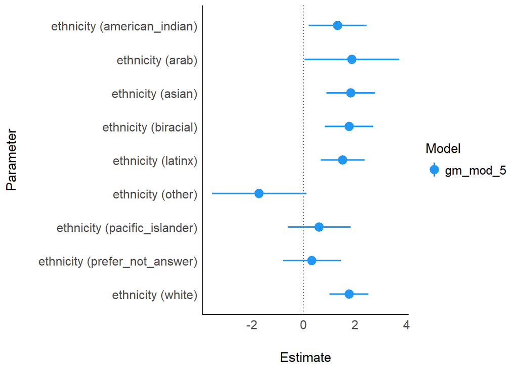

Well awesome, this gives us a great place that we can start in further data analysis in our project.

[figure not shown]

### [**NEXT**](https://pbischoff3.github.io/Projects/BIOL_3100/models/per_com_orient/)